# Analysis of distribution shape

```r
library(diptest)
library(multimode)
library(EnvStats)
library(purrr)
```

As gene overexpression was not always able to identify fusion genes, further research was conducted into utilising the shape of the gene distribution. This was inspired by de Torrente et al., (2020) who classified gene expression into one of six shapes before conducting differential expression analysis. This enabled a more sensitive approach.

6 distrib -2 symmetric: normal and cauchy (heavy tails, more peaked) -skewed, asymmetric: lognormal, pareto, gamma -2 distinct subgroups in data: bimodal

-when normal - compare tails to non tails - picked the 10 -when asymmetric - extreme was 1st/last percentile - depending on shape of asymm -bimodal - split determined by clustering algorithm

To simplify this analysis, we attempted to classify a gene distribution into one of 3 shapes: -bimodal -normal -skewed (left or right tail)

# Bimodality

-the package used in the paper (ClassDiscovery) has the bimodal test in an old version that I can't download

instead used multimode and diptest diptest was slightly more conservative but was faster to run

# bimodality

so the package used in the paper (ClassDiscovery) has the bimodal test in an old version that I can't download https://bioinformatics.mdanderson.org/Software/OOMPA/Current/ClassDiscovery-manual.pdf https://journals.sagepub.com/doi/10.4137/cin.s2846?url_ver=Z39.88-2003&rfr_id=ori:rid:crossref.org&rfr_dat=cr_pub%20%200pubmed -therefore abandon this route -instead use package multimode https://towardsdatascience.com/modelling-bimodal-distributions-with-multimode-in-r-94dbb884abc9 -uses the dip test (I think) -anyway it has H0 as univariate, H2 as multimodes -so if p < 0.05 then bimodal -can then find point of multimode

-the ERG prostate adenocarcinoma bimodal distribution was used for this analysis

```
There were 22 warnings (use warnings() to see them)
```

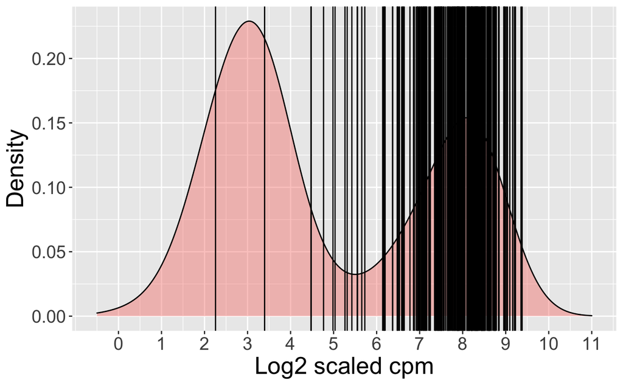

```r
erg_prostate
```

```r
try.bimodal <- erg_counts %>%
  filter(has_cancer == "Cancer") %>%
  filter(Cancer == "Prostate Adenocarcinoma")
try.bimodal
```

|  | Counts | rail_id | Cancer | Tissue | Project_ID | ID | auc | mapped | auc_norm | mapped_norm | log2_Counts | log2_auc_norm | log2_map_norm | has_cancer | cancer_status | fusion |
| --- | --- | --- | --- | --- | --- | --- | --- | --- | --- | --- | --- | --- | --- | --- | --- | --- |
| rail_70652 | 3528628 | rail_70652 | Prostate Adenocarcinoma | Prostate | PRAD | TCGA-VP-A87D-01A-11R-A352-07 | 5293044609 | 110856774 | 666.6537429 | 31830.51313 | 21.75068 | 9.38079382 | 14.958123 | Cancer | Cancer | Fusion |
| rail_62826 | 3593084 | rail_62826 | Prostate Adenocarcinoma | Prostate | PRAD | TCGA-YL-A8SL-01B-21R-A37L-07 | 5484488390 | 115050642 | 655.1356744 | 31230.45589 | 21.77679 | 9.35564990 | 14.930666 | Cancer | Cancer | Fusion |
| rail_69971 | 4534607 | rail_69971 | Prostate Adenocarcinoma | Prostate | PRAD | TCGA-EJ-8472-01A-11R-2403-07 | 7571941058 | 158523559 | 598.8698228 | 28605.25608 | 22.11255 | 9.22609863 | 14.803993 | Cancer | Cancer | Fusion |
| rail_63840 | 3574357 | rail_63840 | Prostate Adenocarcinoma | Prostate | PRAD | TCGA-YL-A8HL-01A-11R-A36G-07 | 6055058090 | 126928347 | 590.3092831 | 28160.43133 | 21.76925 | 9.20532722 | 14.781382 | Cancer | Cancer | Fusion |
| rail_66920 | 3015631 | rail_66920 | Prostate Adenocarcinoma | Prostate | PRAD | TCGA-EJ-5496-01A-01R-1580-07 | 5255531964 | 110246022 | 573.8012861 | 27353.64910 | 21.52403 | 9.16440739 | 14.739446 | Cancer | Cancer | Fusion |
| rail_60479 | 3479167 | rail_60479 | Prostate Adenocarcinoma | Prostate | PRAD | TCGA-EJ-7321-01A-31R-2263-07 | 6068824057 | 126987167 | 573.2851978 | 27397.78422 | 21.73031 | 9.16310922 | 14.741772 | Cancer | Cancer | Fusion |
| rail_61904 | 3716076 | rail_61904 | Prostate Adenocarcinoma | Prostate | PRAD | TCGA-VP-A87K-01A-11R-A352-07 | 6792140220 | 142394763 | 547.1141466 | 26096.99909 | 21.82535 | 9.09569805 | 14.671596 | Cancer | Cancer | Fusion |
| rail_61320 | 2977839 | rail_61320 | Prostate Adenocarcinoma | Prostate | PRAD | TCGA-2A-AAYU-01A-11R-A41O-07 | 5656882395 | 118612291 | 526.4099184 | 25105.65284 | 21.50583 | 9.04004286 | 14.615725 | Cancer | Cancer | Fusion |
| rail_70938 | 2681503 | rail_70938 | Prostate Adenocarcinoma | Prostate | PRAD | TCGA-CH-5741-01A-11R-1580-07 | 5203220305 | 108997079 | 515.3545003 | 24601.60423 | 21.35461 | 9.00942136 | 14.586465 | Cancer | Cancer | Fusion |
| rail_63027 | 3416181 | rail_63027 | Prostate Adenocarcinoma | Prostate | PRAD | TCGA-HC-7213-01A-11R-2118-07 | 6769502415 | 142229716 | 504.6428512 | 24018.75709 | 21.70395 | 8.97911891 | 14.551874 | Cancer | Cancer | Fusion |

[output cut: 496 more lines]

```r
modetest(try.bimodal$log2_auc_norm)
```

```
    Ameijeiras-Alonso et al. (2019) excess mass test

data:  try.bimodal$log2_auc_norm
Excess mass = 0.14966, p-value < 2.2e-16
alternative hypothesis: true number of modes is greater than 1
```

```
If the density function has an unbounded support, artificial modes may have been created in the tails
```

```
Estimated location
Modes: 3.245688  8.268511
Antimode: 5.276712

Estimated value of the density
Modes: 0.2777287  0.2025763
Antimode: 0.02252289

Critical bandwidth: 0.2910614
```

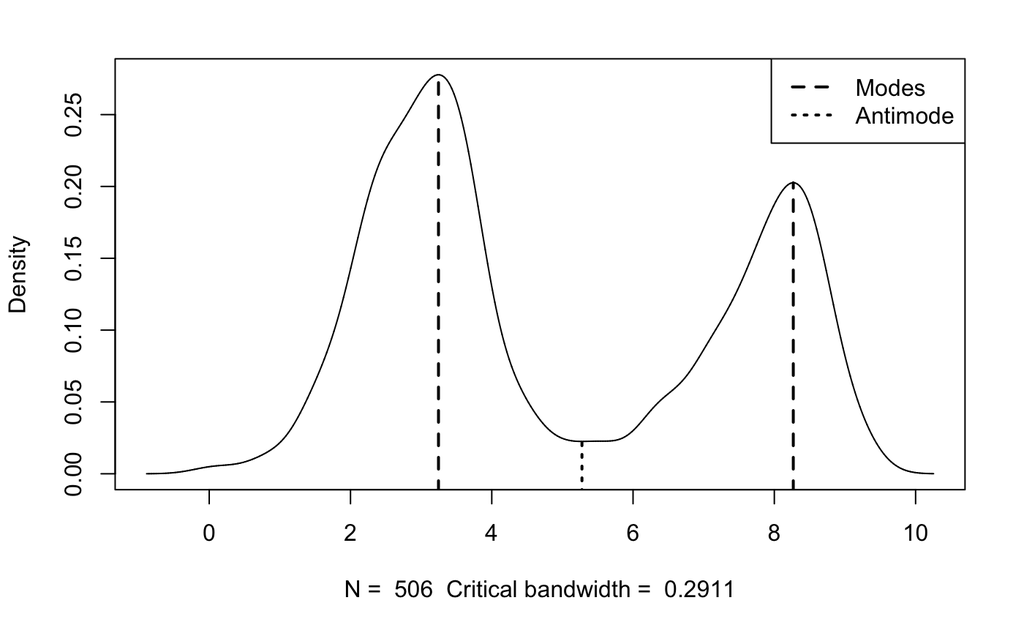

```r
locmodes(try.bimodal$log2_auc_norm, mod0=2, display=TRUE)
```

overexpression was defined from the dip point (antimode) corresponding to 5.277 log2 cpm 202 samples were identified as overexpressed through this 196 fusions were captured this was a true positive sensitivity of 96%

# Normal

To simplify the workflow (maintaining a low computational complexity), normality was defined in conjunction with skewness Overexpression was maintained as samples above the 95th percentile

# Skewed

Skewness was determined using the skewness test. skew < - 1 was taken to be a left tailed distribution (NA) skew > 1 right tailed distribution (overexpression above 90th percentile) a skew between [-1,1] was taken to approximate the normal distribution

This was tested using the ETV1 prostate adenocarcinoma samples.

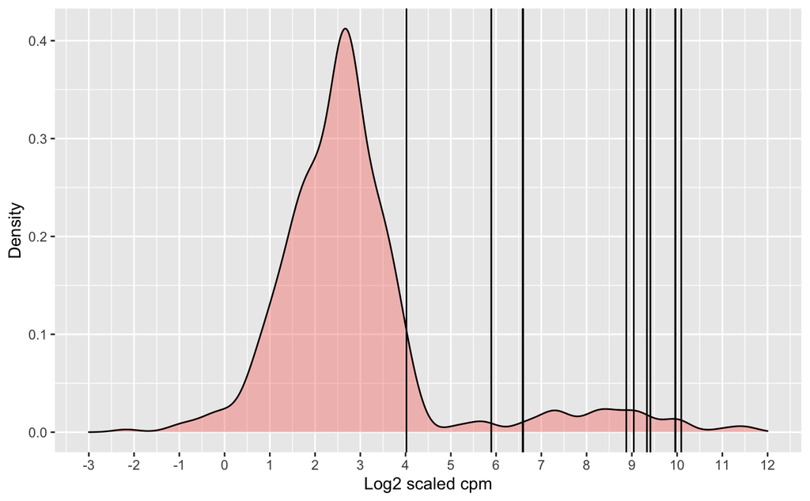

```r
etv1_prostate <- etv1_combined %>%
  filter(has_cancer == "Cancer", Tissue == "Prostate") %>%
  ggplot(aes(x = log2_auc_norm, fill = Project_ID)) +
  geom_density(alpha = 0.4) +
  geom_vline(aes(xintercept = log2_auc_norm), data = . %>% filter(fusion == "Fusion")) +
  theme(legend.position = "none") +
  scale_x_continuous(breaks = c(-3:12), limits = c(-3,12)) +
  labs(x = "Log2 scaled cpm", y = "Density")
etv1_prostate
```

[output not shown]

ETV1 has a skew of 1.937 in prostate adenocarcinoma, identifying it as a right-tailed distribution. Identifying overexpression as samples above the 90th percentile, this enabled a true positive sensitivity of 90.1%

# Combining analysis

```r
shape_for_heatmap <- function(gene) {
  counts <-  gene %>%
    filter(has_cancer == "Cancer") %>%
    group_by(Project_ID) %>%
    distinct(Project_ID) %>%
    .[order(.$Project_ID),]
  bimodal <- gene %>%
    filter(has_cancer == "Cancer") %>%
    split(f = list(as.character(.$Project_ID))) %>%
    map(~dip.test(.x$log2_auc_norm)$p.value) %>%
    unlist(., .$Project_ID) %>%
    data.frame(.)
  colnames(bimodal) <- "p.val"
  counts$bimodal_p.value <- bimodal$p.val
  skewness <- gene %>%
    filter(has_cancer == "Cancer") %>%
    split(f = list(as.character(.$Project_ID))) %>%
    map(~skewness(.x$log2_auc_norm)) %>%
    unlist(., .$Project_ID) %>%
    data.frame(.)
  colnames(skewness) <- "skew"
  counts$skew <- skewness$skew
  counts <- data.frame(t(counts))
  colnames(counts) <- counts[1,]
  counts <- counts[-1,]
  counts <- counts %>%
    t(.) %>% data.frame() %>% type.convert(.) %>%
    transform(skew = ifelse(bimodal_p.value <= 0.05, "NA", skew)) %>%
    t(.) %>% data.frame()
  counts
}

#gtex
shape_for_heatmap_gtex <- function(gene) {
  counts <-  gene %>%
    filter(has_cancer == "GTEx") %>%
    group_by(Tissue) %>%
    distinct(Tissue) %>%
    .[order(.$Tissue),]
  bimodal <- gene %>%
    filter(has_cancer == "GTEx") %>%
    split(f = list(as.character(.$Tissue))) %>%
    map(~dip.test(.x$log2_auc_norm)$p.value) %>%
    unlist(., .$Tissue) %>%
    data.frame(.)
  colnames(bimodal) <- "p.val"
  counts$bimodal_p.value <- bimodal$p.val
  skewness <- gene %>%
    filter(has_cancer == "GTEx") %>%
    split(f = list(as.character(.$Tissue))) %>%
    map(~skewness(.x$log2_auc_norm)) %>%
    unlist(., .$Tissue) %>%
    data.frame(.)
  colnames(skewness) <- "skew"
  counts$skew <- skewness$skew
  counts <- data.frame(t(counts))
  colnames(counts) <- counts[1,]
  counts <- counts[-1,]
  counts <- counts %>%
    t(.) %>% data.frame() %>% type.convert(.) %>%
    transform(skew = ifelse(bimodal_p.value <= 0.05, "NA", skew)) %>%
    t(.) %>% data.frame()
  counts
}

#normal
shape_for_heatmap_normal <- function(gene) {
  counts <-  gene %>%
    filter(has_cancer == "Normal") %>%
    group_by(Tissue) %>%
    distinct(Tissue) %>%
    .[order(.$Tissue),]
  bimodal <- gene %>%
    filter(has_cancer == "Normal") %>%
    split(f = list(as.character(.$Tissue))) %>%
    map(~dip.test(.x$log2_auc_norm)$p.value) %>%
    unlist(., .$Tissue) %>%
    data.frame(.)
  colnames(bimodal) <- "p.val"
  counts$bimodal_p.value <- bimodal$p.val
  skewness <- gene %>%
    filter(has_cancer == "Normal") %>%
    split(f = list(as.character(.$Tissue))) %>%
    map(~skewness(.x$log2_auc_norm)) %>%
    unlist(., .$Tissue) %>%
    data.frame(.)
  colnames(skewness) <- "skew"
  counts$skew <- skewness$skew
  counts <- data.frame(t(counts))
  colnames(counts) <- counts[1,]
  counts <- counts[-1,]
  counts <- counts %>%
    t(.) %>% data.frame() %>% type.convert(.) %>%
    transform(skew = ifelse(bimodal_p.value <= 0.05, "NA", skew)) %>%
    t(.) %>% data.frame()
  counts
}
```

```r
shape_in_words3 <- function(heat) {
  shape <- heat
  shape <- shape[2,] %>%
    t(.) %>%
    data.frame() %>%
    type.convert()
  shape <- shape %>% mutate(words = case_when((skew >= -1) & (skew <= 1) ~ "Normal",
          (skew < -1) ~ "Left tail",
          (skew > 1) ~ "Right tail")) %>%
          replace_na(list(words = "Bimodal"))
  shape
}
```

The functions are able to identify the distribution shape and the name of the shape. However, using this information to then specify an overexpression threshold for individual cancer types was beyond the scope of this thesis.

# heatmaps of skew and bimodality for TCGA and GTEx

```r
erg_heat <- shape_for_heatmap(erg_counts)
maml3_heat <- shape_for_heatmap(maml3_counts)
tfe3_heat <- shape_for_heatmap(tfe3_counts)
tmprss2_heat <- shape_for_heatmap(tmprss2_counts)
rara_heat <- shape_for_heatmap(rara_counts)
tacc3_heat <- shape_for_heatmap(tacc3_counts)
ret_heat <- shape_for_heatmap(ret_counts)
etv1_heat <- shape_for_heatmap(etv1_counts)
ntrk3_heat <- shape_for_heatmap(ntrk3_counts)
#alk_heat <- shape_for_heatmap(alk_counts)
arhgap26_heat <- shape_for_heatmap(arhgap26_counts)
```

```r
bimodal_heat <- rbind(erg_heat[1,], maml3_heat[1,], tfe3_heat[1,], tmprss2_heat[1,], rara_heat[1,], tacc3_heat[1,], ret_heat[1,], etv1_heat[1,], ntrk3_heat[1,], arhgap26_heat[1,])
rownames(bimodal_heat) <- c("ERG", "MAML3", "TFE3", "TMPRSS2", "RARA", "TACC3", "RET", "ETV1", "NTRK3", "ARHGAP26")
bimodal_heat <- type.convert(bimodal_heat)

skew_heat <- rbind(erg_heat[2,], maml3_heat[2,], tfe3_heat[2,], tmprss2_heat[2,], rara_heat[2,], tacc3_heat[2,], ret_heat[2,], etv1_heat[2,], ntrk3_heat[2,], arhgap26_heat[2,])
rownames(skew_heat) <- c("ERG", "MAML3", "TFE3", "TMPRSS2", "RARA", "TACC3", "RET", "ETV1", "NTRK3", "ARHGAP26")
skew_heat <- type.convert(skew_heat)
```

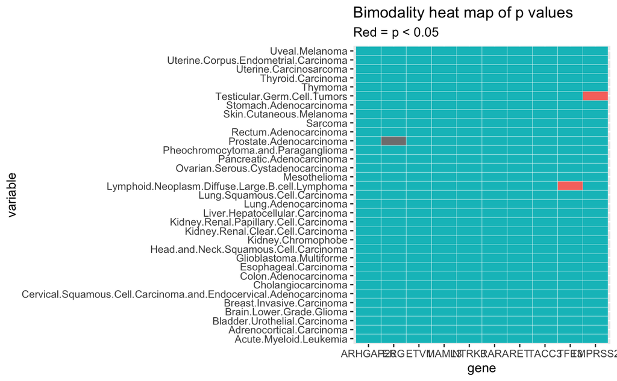

```r
bimodal_heat %>% melt(.) %>%
  mutate(gene = rep(c("ERG", "MAML3", "TFE3", "TMPRSS2", "RARA", "TACC3", "RET", "ETV1", "NTRK3", "ARHGAP26"), times = 33), .before = variable) %>%
  mutate(groups = cut(.$value, breaks = c(1, 0.05, 0))) %>%
  ggplot(., aes(gene, variable, fill = groups)) +
  geom_tile(colour = "white", linetype = 1) +
  scale_fill_discrete(breaks = levels(groups)) +
  labs(title = "Bimodality heat map of p values", subtitle = "Red = p < 0.05")
```

[figure not shown]

```r
skew_heat %>% melt(.) %>%
  mutate(gene = rep(c("ERG", "MAML3", "TFE3", "TMPRSS2", "RARA", "TACC3", "RET", "ETV1", "NTRK3", "ARHGAP26"), times = 33), .before = variable) %>%
  ggplot(., aes(gene, variable)) +
  geom_tile(aes(fill = value), colour = "white", linetype = 1) +
  scale_fill_stepsn(colours = c("darkblue", "white",
                                  "darkgreen"),
                       breaks= c(-1, 1)) +
  labs(title = "Skew heat map", subtitle = "purple = left tail, darkgreen = right tail")
```

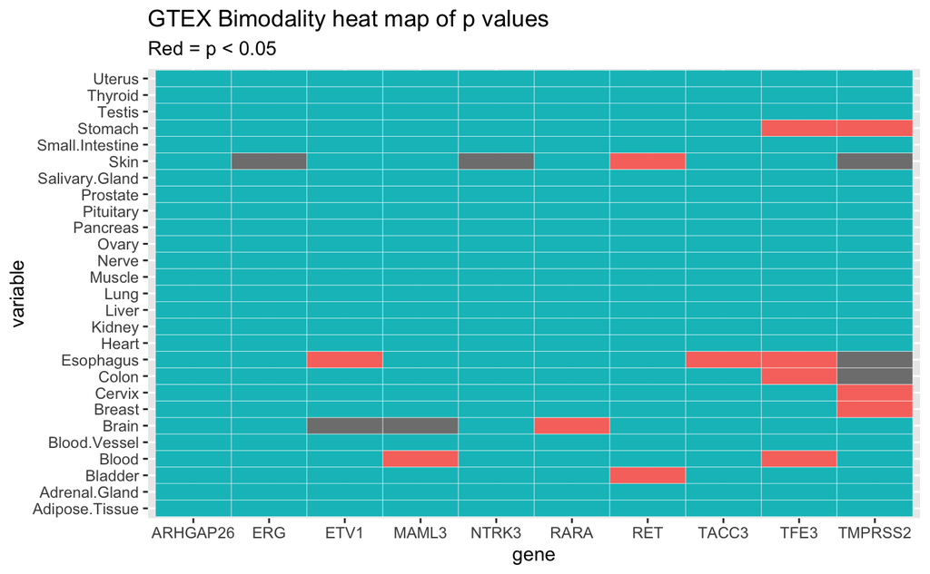

```r
bimodal_heat_gtex %>% melt(.) %>%
  mutate(gene = rep(c("ERG", "MAML3", "TFE3", "TMPRSS2", "RARA", "TACC3", "RET", "ETV1", "NTRK3", "ARHGAP26"), times = 27), .before = variable) %>%
  mutate(groups = cut(.$value, breaks = c(1, 0.05, 0))) %>%
  ggplot(., aes(gene, variable, fill = groups)) +
  geom_tile(colour = "white", linetype = 1) +
  scale_fill_discrete(breaks = levels(groups)) +
  labs(title = "GTEX Bimodality heat map of p values", subtitle = "Red = p < 0.05")
```

[figure not shown]

```r
skew_heat_gtex %>% melt(.) %>%
  mutate(gene = rep(c("ERG", "MAML3", "TFE3", "TMPRSS2", "RARA", "TACC3", "RET", "ETV1", "NTRK3", "ARHGAP26"), times = 27), .before = variable) %>%
  ggplot(., aes(gene, variable)) +
  geom_tile(aes(fill = value), colour = "white", linetype = 1) +
  scale_fill_stepsn(colours = c("darkblue", "white",
                                  "darkgreen"),
                       breaks= c(-1, 1)) +
  labs(title = " GTEX Skew heat map", subtitle = "purple = left tail, darkgreen = right tail")
```

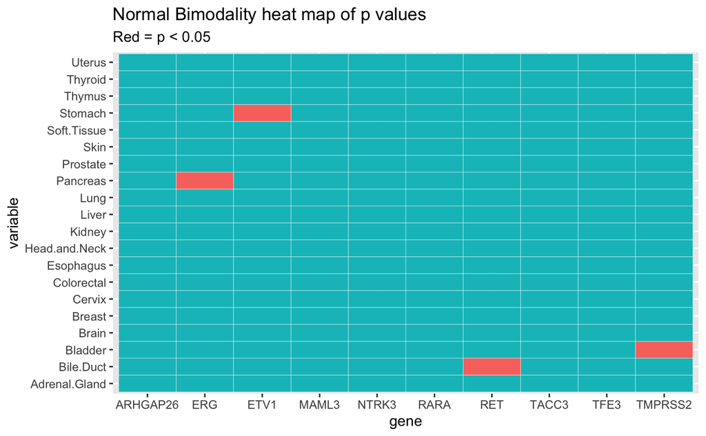

```r
bimodal_heat_norm %>% melt(.) %>%
  mutate(gene = rep(c("ERG", "MAML3", "TFE3", "TMPRSS2", "RARA", "TACC3", "RET", "ETV1", "NTRK3", "ARHGAP26"), times = 20), .before = variable) %>%
  mutate(groups = cut(.$value, breaks = c(1, 0.05, 0))) %>%
  ggplot(., aes(gene, variable, fill = groups)) +
  geom_tile(colour = "white", linetype = 1) +
  scale_fill_discrete(breaks = levels(groups)) +
  labs(title = "Normal Bimodality heat map of p values", subtitle = "Red = p < 0.05")
```

```r
skew_heat_norm %>% melt(.) %>%
  mutate(gene = rep(c("ERG", "MAML3", "TFE3", "TMPRSS2", "RARA", "TACC3", "RET", "ETV1", "NTRK3", "ARHGAP26"), times = 20), .before = variable) %>%
  ggplot(., aes(gene, variable)) +
  geom_tile(aes(fill = value), colour = "white", linetype = 1) +
  scale_fill_stepsn(colours = c("darkblue", "white",
                                  "darkgreen"),
                       breaks= c(-1, 1)) +
  labs(title = "Normal Skew heat map", subtitle = "purple = left tail, darkgreen = right tail")
```

[output not shown]

```r
#gtex
gtex_erg_heat <- shape_for_heatmap_gtex(erg_combined)
gtex_maml3_heat <- shape_for_heatmap_gtex(maml3_combined)
gtex_tfe3_heat <- shape_for_heatmap_gtex(tfe3_combined)
gtex_tmprss2_heat <- shape_for_heatmap_gtex(tmprss2_combined)
gtex_rara_heat <- shape_for_heatmap_gtex(rara_combined)
gtex_tacc3_heat <- shape_for_heatmap_gtex(tacc3_combined)
gtex_ret_heat <- shape_for_heatmap_gtex(ret_combined)
gtex_etv1_heat <- shape_for_heatmap_gtex(etv1_combined)
gtex_ntrk3_heat <- shape_for_heatmap_gtex(ntrk3_combined)
#alk_heat <- shape_for_heatmap(alk_counts)
gtex_arhgap26_heat <- shape_for_heatmap_gtex(arhgap26_combined)
bimodal_heat_gtex <- rbind(gtex_erg_heat[1,], gtex_maml3_heat[1,], gtex_tfe3_heat[1,], gtex_tmprss2_heat[1,], gtex_rara_heat[1,], gtex_tacc3_heat[1,], gtex_ret_heat[1,], gtex_etv1_heat[1,], gtex_ntrk3_heat[1,], gtex_arhgap26_heat[1,])
rownames(bimodal_heat_gtex) <- c("ERG", "MAML3", "TFE3", "TMPRSS2", "RARA", "TACC3", "RET", "ETV1", "NTRK3", "ARHGAP26")
bimodal_heat_gtex <- type.convert(bimodal_heat_gtex)
skew_heat_gtex <- rbind(gtex_erg_heat[2,], gtex_maml3_heat[2,], gtex_tfe3_heat[2,], gtex_tmprss2_heat[2,], gtex_rara_heat[2,], gtex_tacc3_heat[2,], gtex_ret_heat[2,], gtex_etv1_heat[2,], gtex_ntrk3_heat[2,], gtex_arhgap26_heat[2,])
rownames(skew_heat_gtex) <- c("ERG", "MAML3", "TFE3", "TMPRSS2", "RARA", "TACC3", "RET", "ETV1", "NTRK3", "ARHGAP26")
skew_heat_gtex <- type.convert(skew_heat_gtex)
#normal
norm_erg_heat <- shape_for_heatmap_normal(erg_combined)
```

[output not shown]

```r
norm_maml3_heat <- shape_for_heatmap_normal(maml3_combined)
```

[output not shown]

```r
norm_tfe3_heat <- shape_for_heatmap_normal(tfe3_combined)
```

[output not shown]

```r
norm_tmprss2_heat <- shape_for_heatmap_normal(tmprss2_combined)
```

[output not shown]

```r
norm_rara_heat <- shape_for_heatmap_normal(rara_combined)
```

[output not shown]

```r
norm_tacc3_heat <- shape_for_heatmap_normal(tacc3_combined)
```

[output not shown]

```r
norm_ret_heat <- shape_for_heatmap_normal(ret_combined)
```

[output not shown]

```r
norm_etv1_heat <- shape_for_heatmap_normal(etv1_combined)
```

[output not shown]

```r
norm_ntrk3_heat <- shape_for_heatmap_normal(ntrk3_combined)
```

[output not shown]

```r
#alk_heat <- shape_for_heatmap(alk_counts)
norm_arhgap26_heat <- shape_for_heatmap_normal(arhgap26_combined)
```

[output not shown]

```r
bimodal_heat_norm <- rbind(norm_erg_heat[1,], norm_maml3_heat[1,], norm_tfe3_heat[1,], norm_tmprss2_heat[1,], norm_rara_heat[1,], norm_tacc3_heat[1,], norm_ret_heat[1,], norm_etv1_heat[1,], norm_ntrk3_heat[1,], norm_arhgap26_heat[1,])
rownames(bimodal_heat_norm) <- c("ERG", "MAML3", "TFE3", "TMPRSS2", "RARA", "TACC3", "RET", "ETV1", "NTRK3", "ARHGAP26")
bimodal_heat_norm <- type.convert(bimodal_heat_norm)
skew_heat_norm <- rbind(norm_erg_heat[2,], norm_maml3_heat[2,], norm_tfe3_heat[2,], norm_tmprss2_heat[2,], norm_rara_heat[2,], norm_tacc3_heat[2,], norm_ret_heat[2,], norm_etv1_heat[2,], norm_ntrk3_heat[2,], norm_arhgap26_heat[2,])
rownames(skew_heat_norm) <- c("ERG", "MAML3", "TFE3", "TMPRSS2", "RARA", "TACC3", "RET", "ETV1", "NTRK3", "ARHGAP26")
skew_heat_norm <- type.convert(skew_heat_norm)
```

# comparing skewed vs non skewed in regards to positions of fusions

-tacc3 fusion cancer gtex -Glioblastoma Multiforme 12.12 100% >100% right tail -Bladder Urothelial Carcinoma 7.978 - 9.381 >97% >100% -Cervix 6.116 - 9.881 >30% >100% -gross -Lung Squamous Cell Carcinoma 4.517 - 9.063 >5% >69% -yuck -Lung Adenocarcinoma 8.477 100% >100% -Brain Lower Grade Glioma 5.318 - 9.075 >90% >100% -Kidney Renal Papillary Cell Carcinoma 3.18 - 9.37 >34% >67% -gross right tail -Head and Neck Squamous Cell Carcinoma 8.581 - 8.727 >99% NA -Esophageal Carcinoma 6.456 - 6.557 >91% >99% -Acute Myeloid Leukemia 7.094 >97% >71%

-ret -Thyroid Carcinoma 3.471 - 7.540 >90% >90%  
-Breast Invasive Carcinoma 4.755 >53% >100% -gross -Colon Adenocarcinoma 5.23 >99% >97% -Ovarian Serous Cystadenocarcinoma 2.611 >72% >63% -meh -Lung Adenocarcinoma 3.667 - 3.767 >88% >16% right tail -Acute Myeloid Leukemia -0.6016 29% <0%

-etv1 -Brain Lower Grade Glioma 11.19 100% >100% left tail -Prostate Adenocarcinoma 4.018 - 10.093 >89% >93% right tail

-ntrk3 -Breast Invasive Carcinoma 7.266 >99% >100% -Thyroid Carcinoma 3.733 - 6.13 >83% >94% -Colon Adenocarcinoma 1.638 - 6.204 >96% >1% -lots of negatives in cancer -Skin Cutaneous Melanoma 6.047 >99% >94% -lots of negatives in cancer -Brain Lower Grade Glioma 5.642 >8% >100% -yuck left tail -Pancreatic Adenocarcinoma 4.971 100% >100% 66% < 1 -Cervix 3.807 >99% >92% -mostly negatives -Head and Neck Squamous Cell Carcinoma 1.872 >97% NA -mostly negatives

-alk -Thyroid Carcinoma 3.131 - 11.164 >94% >80% -mostly <1 -Sarcoma 10.13 100% NA mostly neg -Skin Cutaneous Melanoma 2.316 - 8.608 >66% >9% 40% <1 -meh -Bladder Urothelial Carcinoma 6.816 100% >100% -mostly neg 97% <1 -Kidney Renal Papillary Cell Carcinoma 3.912 - 5.656 >99% >84% -mostly neg 93% <1 -Lung Adenocarcinoma 2.092 - 5.144 >97% >0% -mostly neg 94% < 1 -Rectum Adenocarcinoma 2.95 100% NA 99% neg

-arhgap26 -Stomach Adenocarcinoma 4.688 - 5.973 >22% <90%  
-Sarcoma 5.838 97% NA  
-Cervix 6.027 >87% >100% -Lung Squamous Cell Carcinoma 5.123 >89% >94% -Lung Adenocarcinoma 4.244 - 4.984 >25% >53% -Head and Neck Squamous Cell Carcinoma 4.055 >68% NA

-the only 2 right tailed distribs in tacc3 have fusions -3 left tailed distrib (colon adeno, testic, thymoma) - no fusions -2 ret right tail - 1 fusion other uveal, 2 left tail - no fusions -1 etv1 right tail - fusion, 4 left tail - 1 fusion -1 ntrk3 right tail - no fusion, 1 left tail - fusion -0 arhgap26 right tail, 2 left tail - no fusion